# Bellabeats Case Study

Christian Collins 2024-05-13

## About Bellabeat

Urška Sršen and Sando Mur founded Bellabeat, a high-tech company that manufactures health-focused smart products. Sršen used her background as an artist to develop beautifully designed technology that informs and inspires women around the world. Collecting data on activity, sleep, stress, and reproductive health has allowed Bellabeat to empower women with knowledge about their own health and habits. Since it was founded in 2013, Bellabeat has grown rapidly and quickly positioned itself as a tech-driven wellness company for women.

## Business Task

Sršen asks you to analyze smart device usage data in order to gain insight into how consumers use non-Bellabeat smart devices. These questions will guide my analysis: 1. What are some trends in smart device usage? 2. How could these trends apply to Bellabeat customers? 3. How could these trends help influence Bellabeat marketing strategy?

First, I want to find additional data as the [data](https://www.kaggle.com/datasets/arashnic/fitbit) provided to me had a small sample size. I found additional data [here](https://dataverse.no/dataset.xhtml?persistentId=doi:10.18710/TGGCSZ).

## Preparing Data in SQL

After I uploaded the two datasets I began getting to know the data with the preview tab in BigQuery. Then I ran some basic queries to see if the entries match the data description

[figure not shown]

```r
knitr::include_graphics('/cloud/project/Bellabeat_Additional_Data_Id_Count.PNG')
```

[figure not shown]

```r
knitr::include_graphics('/cloud/project/Bellabeat_Sleep_Distinct_Id.PNG')
```

Next, I noticed from previewing the tables that the columns contain the same type of information, but different column names. I confirmed this with the read.me files that came with the dataverse.no dataset. Also, part of this data was collected during COVID. This would skew the results of this data if I left those dates in, because people where in lockdown during this time. So, to fix the formatting and filter out the dates I did not want, I ran the following query:

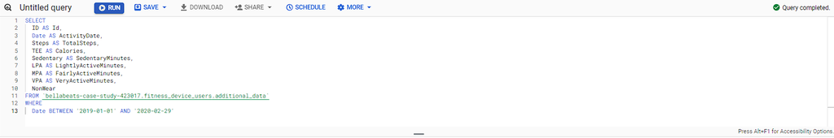

```r
knitr::include_graphics('/cloud/project/Bellabeat_Filter_Data_02.PNG')
```

Now that the tables have the same formant I can merge the two with a `JOIN` statement:

[figure not shown]

```r
knitr::include_graphics('/cloud/project/Bellabeat_Merging_Datasets_02.PNG')
```

The results show a lot of null values after I merged the datasets. I can use `COALESCE` to solve this:

[figure not shown]

```r
knitr::include_graphics('/cloud/project/Bellabeat_Coalesce.png')
```

This looks a lot better, however I want to double check. I can spot check data using the following query and have a split tab open of the dataset before it was merged to make sure the data aligns:

[figure not shown]

```r
knitr::include_graphics('/cloud/project/Bellabeat_Spot_Checking.PNG')
```

## Moving to R

Notes: setting up my R environment by uploading the relevant data, installing and loading the `tidyverse` and `janitor` packages:

```r
install.packages("tidyverse")
install.packages("janitor")
library(tidyverse)
library(janitor)
```

## Preparing and Processing the Data in R

After I imported the data into R I ran the following code to create data frames:

```r
smart_device_users <- read_csv('/cloud/project/smart_device_users.csv')
sleep_df <- read_csv('/cloud/project/sleep_dates_formatted.csv')
```

I have already gotten familiar with this data in SQL, but I can use `glimpse` here to gain an understanding of the data if I hadn’t:

```r
glimpse(smart_device_users)
```

```
## Rows: 40,105
## Columns: 8
## $ Id                   <dbl> 7007744171, 7007744171, 7007744171, 7007744171, 7…
## $ ActivityDate         <date> 2016-04-22, 2016-04-15, 2016-04-16, 2016-04-17, …
## $ TotalSteps           <dbl> 15299, 5273, 4631, 8059, 11085, 3761, 5600, 11179…
## $ Calories             <dbl> 2889, 2098, 2076, 2383, 2667, 2051, 2225, 2668, 2…
## $ SedentaryMinutes     <dbl> 1065, 1238, 1155, 1135, 1021, 1240, 1142, 1096, 1…
## $ LightlyActiveMinutes <dbl> 261, 202, 203, 305, 419, 200, 237, 304, 355, 337,…
## $ FairlyActiveMinutes  <dbl> 50, 0, 0, 0, 0, 0, 0, 6, 8, 12, 13, 14, 16, 17, 2…
## $ VeryActiveMinutes    <dbl> 64, 0, 0, 0, 0, 0, 0, 34, 53, 50, 44, 64, 16, 53,…
```

```r
glimpse(sleep_df)
```

```
## Rows: 413
## Columns: 5
## $ Id                 <dbl> 1503960366, 1503960366, 1503960366, 1503960366, 150…
## $ ActivityDate       <date> 2016-04-12, 2016-04-15, 2016-04-17, 2016-04-19, 20…
## $ TotalSleepRecords  <dbl> 1, 1, 1, 1, 1, 1, 1, 1, 1, 1, 1, 1, 1, 1, 1, 1, 1, …
## $ TotalMinutesAsleep <dbl> 327, 412, 700, 304, 360, 325, 361, 430, 277, 245, 3…
## $ TotalTimeInBed     <dbl> 346, 442, 712, 320, 377, 364, 384, 449, 323, 274, 3…
```

If I’d like a deeper understanding with some statistics I can use `summary`:

```r
summary(smart_device_users)
```

```
##        Id             ActivityDate          TotalSteps       Calories
##  Min.   :1.000e+00   Min.   :2016-04-12   Min.   :    0   Min.   :   0
##  1st Qu.:2.800e+01   1st Qu.:2019-04-19   1st Qu.: 5112   1st Qu.:2021
##  Median :5.800e+01   Median :2019-08-10   Median : 8625   Median :2413
##  Mean   :1.138e+08   Mean   :2019-07-13   Mean   : 9213   Mean   :2344
##  3rd Qu.:8.700e+01   3rd Qu.:2019-11-23   3rd Qu.:12731   3rd Qu.:2851
##  Max.   :8.878e+09   Max.   :2020-02-29   Max.   :75822   Max.   :7769
##  SedentaryMinutes LightlyActiveMinutes FairlyActiveMinutes VeryActiveMinutes
##  Min.   :   0     Min.   :  0.00       Min.   :  0.00      Min.   :  0.00
##  1st Qu.:   0     1st Qu.:  0.00       1st Qu.:  0.00      1st Qu.:  0.00
##  Median :   0     Median :  0.00       Median :  4.00      Median :  3.00
##  Mean   : 269     Mean   : 85.42       Mean   : 15.71      Mean   : 23.38
##  3rd Qu.: 618     3rd Qu.:193.00       3rd Qu.: 21.00      3rd Qu.: 37.00
##  Max.   :1440     Max.   :730.00       Max.   :620.00      Max.   :608.00
```

```r
summary(sleep_df)
```

```
##        Id             ActivityDate        TotalSleepRecords TotalMinutesAsleep
##  Min.   :1.504e+09   Min.   :2016-04-12   Min.   :1.000     Min.   : 58.0
##  1st Qu.:3.977e+09   1st Qu.:2016-04-19   1st Qu.:1.000     1st Qu.:361.0
##  Median :4.703e+09   Median :2016-04-27   Median :1.000     Median :433.0
##  Mean   :5.001e+09   Mean   :2016-04-26   Mean   :1.119     Mean   :419.5
##  3rd Qu.:6.962e+09   3rd Qu.:2016-05-04   3rd Qu.:1.000     3rd Qu.:490.0
##  Max.   :8.792e+09   Max.   :2016-05-12   Max.   :3.000     Max.   :796.0
##  TotalTimeInBed
##  Min.   : 61.0
##  1st Qu.:403.0
##  Median :463.0
##  Mean   :458.6
##  3rd Qu.:526.0
##  Max.   :961.0
```

Something to note is that the average person took 9,213 steps and those who recorded sleep data slept an average of 419 minutes, or 6.98 hours.

## Exploratory Data Analysis in R

First, I’d like to see the relationship between activity and calories burned:

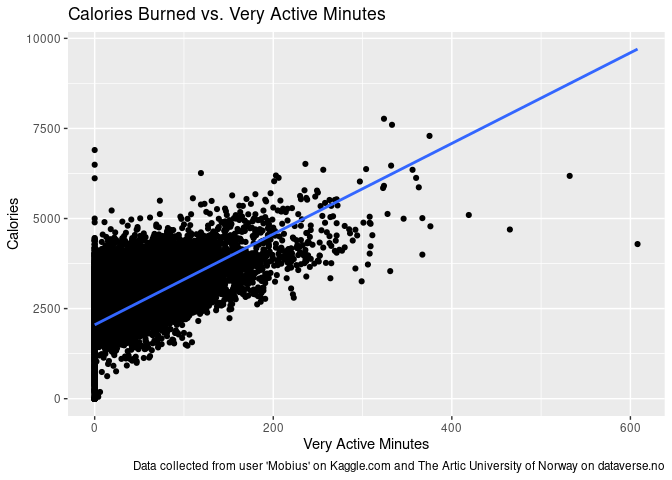

```r
ggplot(smart_device_users, aes(x=VeryActiveMinutes, y=Calories))+geom_point()+geom_smooth(method=lm, se=FALSE)+labs(title= "Calories Burned vs. Very Active Minutes", x="Very Active Minutes", caption = "Data collected from user 'Mobius' on Kaggle.com and The Artic University of Norway on dataverse.no")
```

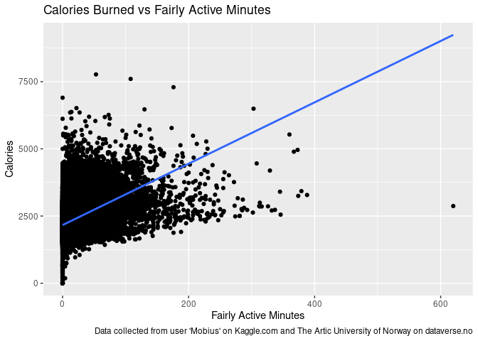

```r
ggplot(smart_device_users, aes(x=FairlyActiveMinutes, y=Calories))+geom_point()+geom_smooth(method=lm, se=FALSE)+labs(title = "Calories Burned vs Fairly Active Minutes", x="Fairly Active Minutes", caption = "Data collected from user 'Mobius' on Kaggle.com and The Artic University of Norway on dataverse.no")
```

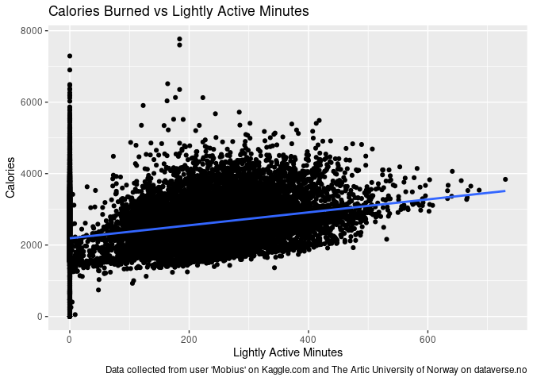

```r
ggplot(smart_device_users, aes(x=LightlyActiveMinutes, y=Calories))+geom_point()+geom_smooth(method=lm, se=FALSE)+labs(title = "Calories Burned vs Lightly Active Minutes", x="Lightly Active Minutes", caption = "Data collected from user 'Mobius' on Kaggle.com and The Artic University of Norway on dataverse.no")
```

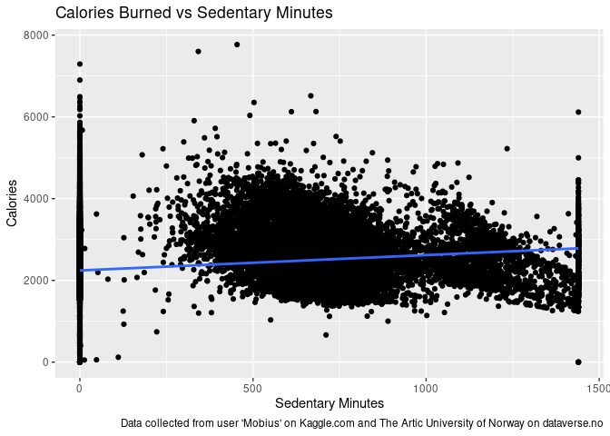

```r
ggplot(smart_device_users, aes(x=SedentaryMinutes, y=Calories))+geom_point()+geom_smooth(method=lm, se=FALSE)+labs(title = "Calories Burned vs Sedentary Minutes", x="Sedentary Minutes", caption = "Data collected from user 'Mobius' on Kaggle.com and The Artic University of Norway on dataverse.no")
```

Graphing all four categories of activity levels I can see that the more active these participants were, the stronger correlation between the activity and calories they burned was. This may be obvious, but checking the data confirms it.

Now that I can see there is a positive correlation between more activity and calories burned, I will see if there is a pattern that more sleep leads to more activity.

First, I need to merge the sleep data with the activity data so that I can plot both data on the same graph. I will merge them using the keys `Id` and `ActivityDate`, so the the correct sleep data merges with the corresponding activity data. I need to use both here, because if I were to just use `Id` the dates may not align leading to skewed results.

```r
total_data <- merge(smart_device_users, sleep_df, by=c("Id","ActivityDate"))
head(total_data)
```

```
##           Id ActivityDate TotalSteps Calories SedentaryMinutes
## 1 1503960366   2016-04-12      13162     1985              728
## 2 1503960366   2016-04-13      10735     1797              776
## 3 1503960366   2016-04-15       9762     1745              726
## 4 1503960366   2016-04-16      12669     1863              773
## 5 1503960366   2016-04-17       9705     1728              539
## 6 1503960366   2016-04-19      15506     2035              775
##   LightlyActiveMinutes FairlyActiveMinutes VeryActiveMinutes TotalSleepRecords
## 1                  328                  13                25                 1
## 2                  217                  19                21                 2
## 3                  209                  34                29                 1
## 4                  221                  10                36                 2
## 5                  164                  20                38                 1
## 6                  264                  31                50                 1
##   TotalMinutesAsleep TotalTimeInBed
## 1                327            346
## 2                384            407
## 3                412            442
## 4                340            367
## 5                700            712
## 6                304            320
```

Now that everything I need is in one place and looks good, I can begin to plot the data to show the relationship between sleep and activity levels:

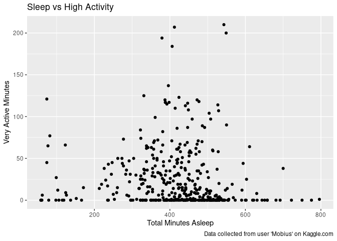

```r
ggplot(total_data, aes(x=TotalMinutesAsleep, y=VeryActiveMinutes))+geom_point()+labs(title = "Sleep vs High Activity", x="Total Minutes Asleep", y="Very Active Minutes", caption = "Data collected from user 'Mobius' on Kaggle.com")
```

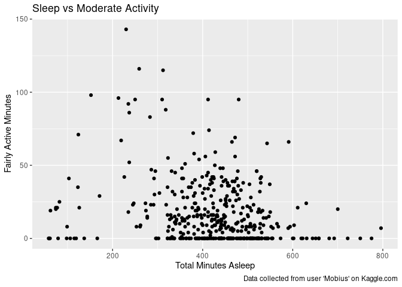

```r
ggplot(total_data, aes(x=TotalMinutesAsleep, y=FairlyActiveMinutes))+geom_point()+labs(title = "Sleep vs Moderate Activity", x="Total Minutes Asleep", y="Fairly Active Minutes", caption = "Data collected from user 'Mobius' on Kaggle.com")
```

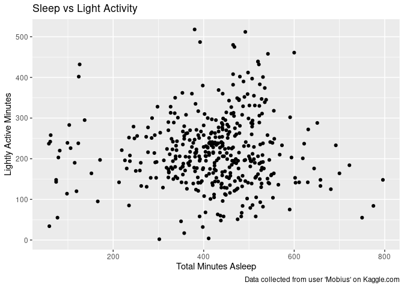

```r
ggplot(total_data, aes(x=TotalMinutesAsleep, y=LightlyActiveMinutes))+geom_point()+labs(title = "Sleep vs Light Activity", x="Total Minutes Asleep", y="Lightly Active Minutes", caption = "Data collected from user 'Mobius' on Kaggle.com")
```

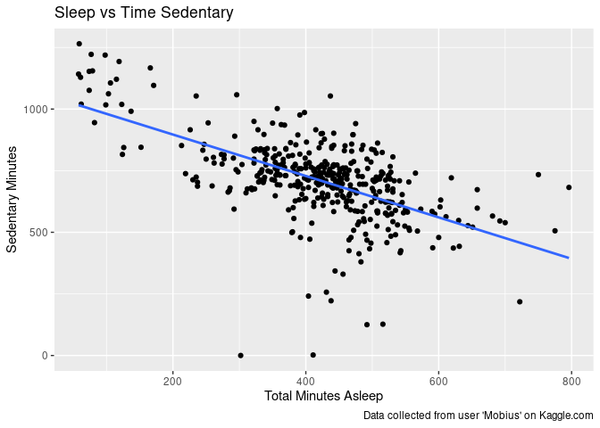

```r
ggplot(total_data, aes(x=TotalMinutesAsleep, y=SedentaryMinutes))+geom_point()+geom_smooth(method=lm, se=FALSE) +labs(title = "Sleep vs Time Sedentary", x="Total Minutes Asleep", y="Sedentary Minutes", caption = "Data collected from user 'Mobius' on Kaggle.com")
```